# Population Ecology

EFB 370: Spring 2026

Prof. [Elie Gurarie](https://eligurarie.github.io/)

[figure not shown]

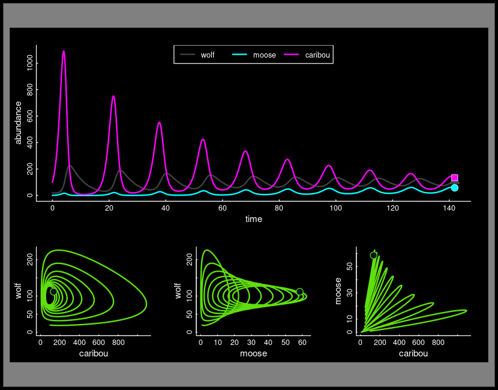

> The study of the rise and fall of populations, inter- and intraspecific interactions - with a strong flavor of conservation biology and management.

## Course Info

**Instructors:**

- **Eliezer (Elie) Gurarie** · egurarie@esf.edu · Illick 206 · Office hours: W 2:15–3:15
- **Joshua Drew** · jadrew@esf.edu · Illick 343 · Office hours: W 2:15–3:15

**TAs:**

- **Kate Henderson** · Kahender@syr.edu · Illick 453 · Office hours: Th 3:00–4:00
- **Gabi Pereira** · glpereir@syr.edu

**Schedule:**

- **Lecture:** MW 12:45–2:05 · Baker 145
- **Recitation:** Th 5:00–6:20 · Baker 309, 314
- **Graduate Session:** Th 3:00–4:00 · Illick 8

# Course Materials

This course is co-taught by Drs. Drew and Gurarie. This page compiles the lectures, labs, problem sets and links to simulation tools for *Dr. Gurarie’s* portion of the course (roughly weeks 5-11). The page will be populated as the course progresses.

## Lectures

#### Topic I. Exponential Growth

Readings: **Gotelli Chapter 1** (on Blackboard)

- 1: Basic Models
- 2: Linear Models for Exponential Growth
- 3a: Demographic Stochasticity Experiment
- 3: Stochasticity
- 3b: Demographic Stochasticity Example: New Zealand Birds

#### Topic II. Limits to Growth

- 4: Limits to Growth - Part I
- 5: Limits to Growth - Part II

#### Topic III. Structured Populations

- 6: Part I - Mainly Matrix Models
- 6b: Matrix Models - A few more slides
- 7: Part II - Life-History Tables

#### Topic IV. Metapopulations

- 8: Metapopulations I
- 9: Metapopulations II

#### Topic V. Multi-Species Interactions

- 11: Competition and Coexistence
- 12: Predation
- 13: Functional Responses

## Recitation/Labs

Many of our labs will use the R programming language. If you use your own computer, be sure to download these two extremely useful (& extremely free) programs: [**R**](https://cran.r-project.org/) and [**Rstudio**](https://posit.co/download/rstudio-desktop/).

- Lab II.1: Introduction to R
- Lab II.2: Linear modeling for population growth
- Lab II.3: Fitting Logistic growth
- Lab II.4: Structured Populations
- Lab II.5: Charismatic Competition
- Lab II.6: Competition and Predation and Competition, Oh My!

## Problem Sets / Homework

- HW 3: Exponential Growth - Due **Thursday, Feb 26**
- HW 4: Density Dependent Growth - Due **Monday, March 9**
- HW 5: Structured Populations) - Due **Thursday March 19**
- HW 6: Competition - Due **Thursday April 2**
- HW 7: Multi-Prey Mayhem - Due **Thursday April 9**

## Interactive Analysis Tools

- [1. Stochastic population simulator](https://egurarie.shinyapps.io/StochasticGrowth/)
- [2. Discrete logistic population simulator](https://egurarie.shinyapps.io/DiscreteLogisticMapping)
- [3. Life history table](https://egurarie.shinyapps.io/AgeStructuredGrowth)
- [4. Matrix Modeller 5000](https://egurarie.shinyapps.io/MatrixPopulationModels/)
- [5. Metapopulation Modeller 3000XC](https://egurarie.shinyapps.io/04_Metapopulations/)
- [6. Squirlicorn vs. Pegamunk: The Final Chapter](https://egurarie.shinyapps.io/SquirlicornVsPegamunk/)
- [7. Messing with Isoclines](https://egurarie.shinyapps.io/isoclines/)
- [8. Predator and Prey](https://egurarie.shinyapps.io/predatorprey/)
- [9. Apparent Competition](https://egurarie.shinyapps.io/apparentcompetition/)